# Demographics component documentation

Katrina Szetey

31/01/2022

# Population and Demographics overview

Forrest has been a regional Victorian township since 1890 and developed around the railway built to transport Otway timber and produce. The population has waxed and waned with its timber and forestry activities, at a peak in the 1960s. With tourism having replaced forestry as the primary economic activity in Forrest, this too may result in volatility in population (especially with the impact on tourism from the Covid-19 pandemic).

## *Problem definition*

*Dynamic hypothesis:* The population in Forrest is ageing due to in-migration of couples without children, and out-migration of young people for school and work after they finish high school. It is limited by housing availability and a lack of diversity in job opportunities.

2. With Forrest Primary School being the central school, pre-school, and childcare service for the community and neighbouring townships, it creates traffic for local businesses in town. It also works with many of the community groups in Forrest. If Forrest were to lose its primary school, there would be many negative knock-on effects causing harm to Forrest’s future, such as out-migration of families seeking access to closer schools.

*Dynamic hypothesis:* The location of the primary school in Forrest makes it a central hub for the neighbouring communities. This brings in regular visitation from people outside of the township who may then go and patronise local businesses. If the school were to close, this regular visitation would likely slow down or cease, and have effects upon those businesses.

```r
# Data for population taken from ABS census data for Forrest as a State Suburb

a = c(170, 45, 106, 20)
b = c(238, 40, 165, 35)
c = c(230, 28, 158, 45)

df <- data.frame(row.names = c("Total", "0-14", "15-64", "65+"), "2006" = a, "2011" = b, "2016" = c)
df <- do.call(rbind, df)
df
```

```
##       [,1] [,2] [,3] [,4]
## X2006  170   45  106   20
## X2011  238   40  165   35
## X2016  230   28  158   45
```

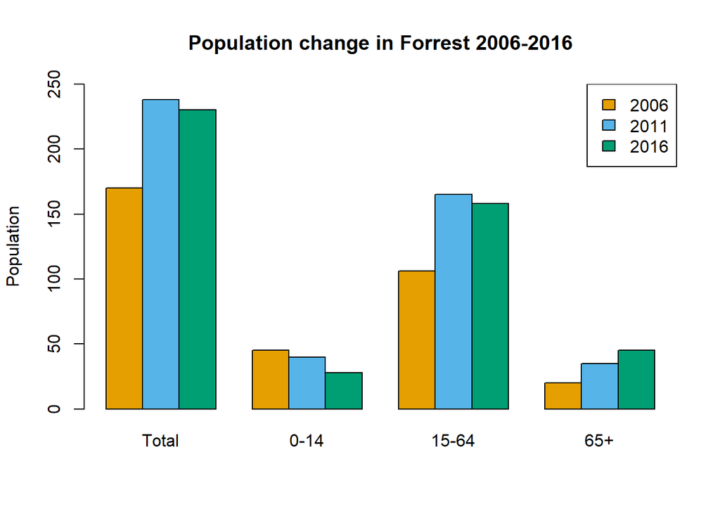

```r
pop <- barplot(df, beside = TRUE, main = "Population change in Forrest 2006-2016",
               names.arg = c("Total", "0-14", "15-64", "65+"), ylim = c(0, 250), ylab = "Population",
               col = c("#E69F00", "#56B4E9", "#009E73"))
legend("topright", legend = c("2006", "2011", "2016"),
       fill = c("#E69F00", "#56B4E9", "#009E73"))
```

## *System conceptualisation*

Migration rates for each cohort are influenced by different characteristics, some of which are modelled (e.g. job availability and housing) and some which are not but are captured within a reference (i.e. initial) migration rate.

School enrolments are made up of local children aged 4-10 (half of the 0-14 cohort) and from ‘district’ children (i.e., from surrounding townships that make up “Forrest and District”).

### Conceptual model

[interactive chart not shown]

## *Model formulation*

The structure of this model component was based upon the model by Navarro and Tapiador (2019). Additional structure was added to incorporate the local school model within this component, and for the different effects on migration rate.

## Data sources

[Data for births.](https://www.abs.gov.au/AUSSTATS/abs@.nsf/DetailsPage/3301.02018?OpenDocument) We used data for the Colac Otway LGA.

Census data for Forrest available [here.](https://www.abs.gov.au/websitedbs/D3310114.nsf/Home/2016%20QuickStats) Data for Forrest as a distinct location is only available for 2006, 2011 and 2016 censuses.

Data for deaths was obtained from ABS.stat, which has now been decommissioned and replaced by [ABS Data Explorer.](https://explore.data.abs.gov.au/) For death rates we had to use state-level data as this was the only way to get age-disaggregated death data.

## *Equations*

### 0-14

Type: Stock  
Formula: INTEG( Births + “In-out migration 0-14” - “Ageing 0-14” - “Deaths 0-14”), INITIAL = 45  
Units: people  
Assumptions/data: Intial value from 2006 census (earliest township-specific census data available)

### Births

Type: Auxiliary (rate)  
Formula: ( “15-64” * fertility rate ) / 2  
Units: people/Year  
Assumptions/data: Number of births per year. Assume half of the 15-64 cohort are able to bear children

### fertility rate

Type: Constant  
Formula: 0.07  
Units: 1/Year  
Assumptions/data: The number of live births per woman aged 15-64 each year. Derived from calibration of the model against data.

### In-out migration 0-14

Type: Auxiliary (rate)  
Formula: “migration rate 0-14” * “0-14”  
Units: people/Year  
Assumptions/data: net migration per year for 0-14 cohort

### migration rate 0-14

Type: Auxiliary  
Formula: “migration rate 15-64” 8 “reference migration rate 0-14”  
Units: 1/Year  
Assumptions/data: Migration rate of 0-14 cohort will be strongly influenced by the migration rate of their parents’ cohort.

### reference migration rate 0-14

Type: Constant  
Formula: -4  
Units: Dmnl  
Assumptions/data: Derived from calibration of the model against data.

### Deaths 0-14

Type: Auxiliary (rate)  
Formula: “mortality rate 0-14” * “0-14”  
Units: people/Year  
Assumptions/data: Number of deaths per year of the 0-14 cohort

### mortality rate 0-14

Type: Constant  
Formula: 0.00031  
Units: 1/Year  
Assumptions/data: Derived from data aggregated at state level

### Ageing 0-14

Type: Auxiliary (rate)  
Formula: “0-14” / “maturation factor 0-14”  
Units: people/Year  
Assumptions/data: Number of population 0-14 moving to next age group

### maturation factor 0-14

Type: Constant  
Formula: 14  
Units: Year  
Assumptions/data: The length of time a person can spend in the cohort before maturing into the next (max age - min age)

### 15-64

Type: Stock  
Formula: INTEG( “Ageing 0-14” + “In-out migration 15-64” - “Ageing 15-64” - “Deaths 15-64”), INITIAL = 106  
Units: people  
Assumptions/data: Intial value from 2006 census (earliest township-specific census data available)

### In-out migration 15-64

Type: Auxiliary (rate)  
Formula: “migration rate 15-64” * “15-64”  
Units: people/Year  
Assumptions/data: Net migration per year for the 15-64 cohort

### migration rate 15-64

Type: Auxiliary  
Formula: “reference 15-64 migration rate” * effect of job availability on migration * effect of housing on migration * job availability unit conversion factor  
Units: 1/Year  
Assumptions/data: Potentially problematic if the reference rate is negative

### reference 15-64 migration rate

Type: Constant  
Formula: 0.02  
Units: 1/Year  
Assumptions/data: Migration rates calibrated against from Otway SA2 data: the average rate for 2017-2019

### job availability unit conversion factor

Type: Constant  
Formula: 1  
Units: people * Year/job  
Assumptions/data: This is a unit correction variable

### effect of job availability on migration

Type: Auxiliary  
Formula: (“job vacancies (agriculture) filled externally”+“job vacancies (other) filled externally”+“job vacancies (tourism) filled externally”) / “working-age population”  
Units: job/(people * Year)  
Assumptions/data: The job to labour force ratio

### Deaths 15-64

Type: Auxiliary (rate)  
Formula: “15-64” * “mortality rate 15-64”  
Units: people/Year  
Assumptions/data: Number of deaths in a year for the 15-64 cohort

### mortality rate 15-64

Type: Constant  
Formula: 0.00156  
Units: 1/Year  
Assumptions/data: Constant derived from data aggregated at state level

### Ageing 15-64

Type: Auxiliary (rate)  
Formula: “15-64” / “maturation factor 15-64”  
Units: people/Year  
Assumptions/data: Number of population 15-64 moving to next age group

### maturation factor 15-64

Type: Constant  
Formula: 49  
Units: Year  
Assumptions/data: Cohort residence time max age - min age

### 65+

Type: Stock  
Formula: INTEG( “Ageing 15-64” + “In-out migration 65+” - “Deaths 65+”), INITAL = 20  
Units: people  
Assumptions/data: Inital value taken from 2006 Census data (earliest township-specific census data available)

### Deaths 65+

Type: Auxiliary (rate)  
Formula: “65+” * “mortality rate 65+”  
Units: people/Year  
Assumptions/data:

### mortality rate 65+

Type: Constant  
Formula: 0.03694  
Units: 1/Year  
Assumptions/data: Derived from data aggregated at state level

### In-out migration 65+

Type: Auxiliary (rate)  
Formula: “migration rate 65+” * “65+”  
Units: people/Year  
Assumptions/data: Net migration per year

### migration rate 65+

Type: Auxiliary  
Formula: “reference 65+ migration rate” * effect of housing on migration  
Units: 1/Year  
Assumptions/data:

### reference migration rate 65+

Type: Constant  
Formula: -0.01  
Units: 1/Year  
Assumptions/data: Derived from calibration of the model against data.

### total population

Type: Auxiliary  
Formula: “0-14” + “15-64” + “65+”  
Units: people  
Assumptions/data: sum of all population cohorts

### School Enrolments

Type: Stock  
Formula: INTEG(New enrolments - Outgoing school cohort), INITIAL = 31  
Units: people  
Assumptions/data: Inital data 31 students enrolled in 2019

### New enrolments

Type: Auxiliary (rate)  
Formula: (( district 0 to 14 cohort + “0-14” )/cohort time * enrolment ratio)  
Units: people/Year  
Assumptions/data: To prevent ‘re-enrolment’ of the same student each year, divide the cohort values by ‘cohort time’ so each enrolment is new.

### cohort time

Type: Constant  
Formula: 7  
Units: Dmnl  
Assumptions/data: To prevent ‘re-enrolment’ of the same student each year, divide the cohort values by 7 so each enrolment is new.

### enrolment ratio

Type: Constant  
Formula: 0.5  
Units: 1/Year  
Assumptions/data: Only half of the 0-14 cohort will enrol at the local primary school (age 4-10)

### district 0-14 cohort

Type: Auxiliary  
Formula: INTEGER (RANDOM NORMAL ( 0, 76, 38, 1, 0 ))  
Units: people  
Assumptions/data: Selecting from a normal distrbution to obtain values for enrolments external to Forrest’s population. The parameters are min = 0, max = 76, mean = 38, SD = 1, based on populations from the townships in the district.

### number of childcare enrolments

Type: Auxiliary  
Formula: INTEGER ( ( district 0 to 14 cohort + “0-14” ) * 0.25)  
Units: people  
Assumptions/data: Arbitrary value of one quarter of 0-14 cohort (have no data for this)

### district kids’ parents cohort

Type: Auxiliary  
Formula: INTEGER ( (district 0 to 14 cohort * 0.75) * 1.5)  
Units: people  
Assumptions/data: Multiply by 1.5 to capture both parents with some wiggle room for single parents etc Multiply by 0.75 to take into account 0.5 enrolment ratio (ie, only half of cohort are of primary school age) and 0.25 for childcare

### Outgoing school cohort

Type: Auxiliary (rate)  
Formula: School Enrolments / maturation of school students  
Units: people/Year  
Assumptions/data:

### maturation of school students

Type: Constant  
Formula: 7  
Units: people  
Assumptions/data: School age cohort tenure time (max age - min age)

# References

Navarro, Andres, and Francisco J. Tapiador. 2019. “RUSEM: A Numerical Model for Policymaking and Climate Applications.” *Ecological Economics* 165 (November): 106403. https://doi.org/10.1016/j.ecolecon.2019.106403.